# Avaliação 1

Econometria Aplicada à Finanças  
Mestrado Profissional em Administração

Autor

Prof. Dr. Washington S. da Silva

Data de Publicação

7 de outubro de 2025

## Questão 1

**a.** Ao longo da disciplina, usaremos o estimador de MQO ($\hat{\beta}$) para estimar um parâmetro $\beta$ de um modelo de regressão linear. Explique, de forma intuitiva, o que significa $\hat{\beta}$ ser viesado para $\beta$.

**b.** Qual é a definição formal (matemática) de **viés**?

**c.** Por que nos importamos se o estimador de MQO (ou qualquer estimador) é **viesado**?

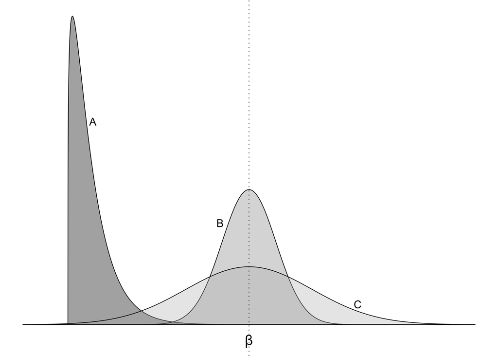

Figura 1: Distribuição Amostral de 3 Estimadores (A, B e C) do parâmetro populacional$ $\beta$.

A Fig. 1 mostra as distribuições de três estimadores (A, B e C), cada um dos quais estima o parâmetro desconhecido $\beta$, sendo que $E[A]= \beta - 3$, $E[B]= \beta$, $E[C]= \beta$.

**d.** Quais dos estimadores exibidos na Fig. 1 são não viesados? *Dica:* Pode haver mais de um.

**e.** Qual dos estimadores da Fig. 1 possui a menor variância?

**f.** Qual dos estimadores da Fig. 1 é o **melhor** estimador não viesado (i.e, com menor variância)?

**g.** O que significa o termo “erro padrão”?

**h.** **Verdadeiro/Falso**: A ausência de viés é uma propriedade para amostras de tamanho finito, enquanto a consistência refere-se a um estimador conforme o tamanho da amostra se aproxima do infinito. Explique sua opção.

**i.** O que significa que um estimador seja **consistente**?

**j.** Qual dos seguintes dois estimadores você escolheria? Explique seu raciocínio.

- Estimador **A** é não viesado e inconsistente.
- Estimador **B** é viesado e consistente.

## Questão 2

Considere uma variável aleatória Y para a qual:

- $E[Y_i] = \mu < \infty$
- As variáveis aleatórias $Y_i$ são independentes.

Utilizando as propriedades do valor experado e do somatório de uma constante ($\sum_{i=1}^n c = nc$).

**a.** Verique se os seguintes estimadores de $\mu$ são não viesados.

$$a = \frac{1}{n} \sum_{i=1}^{n} Y_i + 1.5$$
$$b = \frac{1}{n} \sum_{i=1}^{n} Y_i + \sum_{i=1}^{5} \frac{Y_i}{n}$$

**b.** Pelos resultados do item a), você consegue avaliar se os estimadores são consistentes? Isto é, se cada estimador converge para $\mu$ à medida que $n \rightarrow \infty$